# 05_translate_and_stretch

## 05_translate_and_stretch

#### Question

1. A simple piece-wise function $f$ is plotted below.

   It’s general daughter function, having translations, reflections, and stretches, can be expressed with 4 parameters: $a$, $b$, $h$, and $k$.

   $$g(x) = a\, f(b(x-h))+k$$

   Compared to the parent function, the daughter is stretched vertically by a factor of $a$, stretched horizontally by a factor of $\frac{1}{b}$, and then shifted (translated) right $h$ and shifted up $k$.

   Notice, a left or down shift gives a negative value for $h$ or $k$. Also, a negative stretch factor causes a reflection.

   Each of those four parameters is randomly assigned $2$ or $-2$ or $\frac{1}{2}$ or $-\frac{1}{2}$. Determine the four parameters of the daughter by inspecting the daughter’s graph:

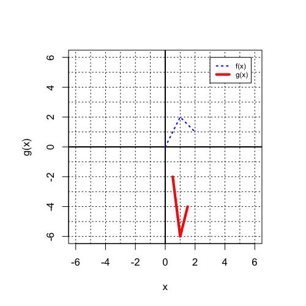

   - $a =$
   - $b =$
   - $h =$
   - $k =$

   Also, write the equation to define the daughter.

   $g(x) =$ $f($ $(x$ $)$

#### Question

2. A simple piece-wise function $f$ is plotted below.

   It’s general daughter function, having translations, reflections, and stretches, can be expressed with 4 parameters: $a$, $b$, $h$, and $k$.

   $$g(x) = a\, f(b(x-h))+k$$

   Compared to the parent function, the daughter is stretched vertically by a factor of $a$, stretched horizontally by a factor of $\frac{1}{b}$, and then shifted (translated) right $h$ and shifted up $k$.

   Notice, a left or down shift gives a negative value for $h$ or $k$. Also, a negative stretch factor causes a reflection.

   Each of those four parameters is randomly assigned $2$ or $-2$ or $\frac{1}{2}$ or $-\frac{1}{2}$. Determine the four parameters of the daughter by inspecting the daughter’s graph:

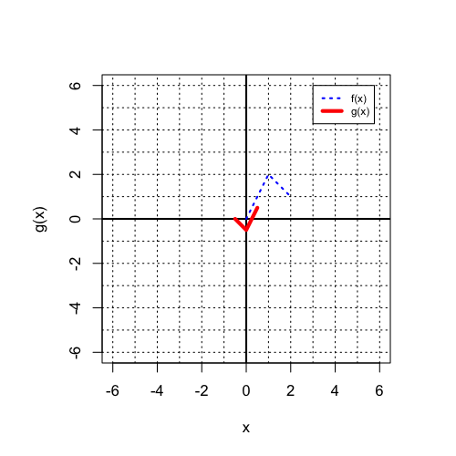

   - $a =$
   - $b =$
   - $h =$
   - $k =$

   Also, write the equation to define the daughter.

   $g(x) =$ $f($ $(x$ $)$

#### Question

3. A simple piece-wise function $f$ is plotted below.

   It’s general daughter function, having translations, reflections, and stretches, can be expressed with 4 parameters: $a$, $b$, $h$, and $k$.

   $$g(x) = a\, f(b(x-h))+k$$

   Compared to the parent function, the daughter is stretched vertically by a factor of $a$, stretched horizontally by a factor of $\frac{1}{b}$, and then shifted (translated) right $h$ and shifted up $k$.

   Notice, a left or down shift gives a negative value for $h$ or $k$. Also, a negative stretch factor causes a reflection.

   Each of those four parameters is randomly assigned $2$ or $-2$ or $\frac{1}{2}$ or $-\frac{1}{2}$. Determine the four parameters of the daughter by inspecting the daughter’s graph:

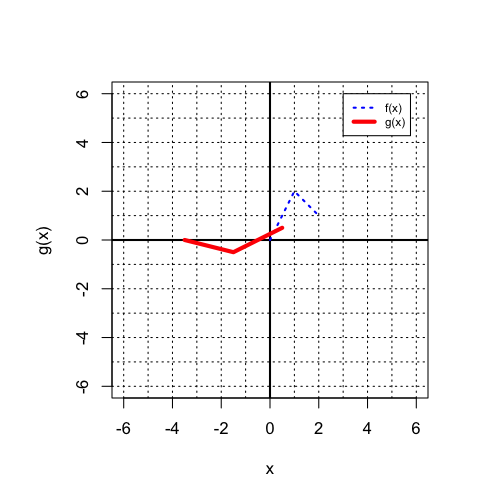

   - $a =$
   - $b =$
   - $h =$
   - $k =$

   Also, write the equation to define the daughter.

   $g(x) =$ $f($ $(x$ $)$

#### Question

4. A simple piece-wise function $f$ is plotted below.

   It’s general daughter function, having translations, reflections, and stretches, can be expressed with 4 parameters: $a$, $b$, $h$, and $k$.

   $$g(x) = a\, f(b(x-h))+k$$

   Compared to the parent function, the daughter is stretched vertically by a factor of $a$, stretched horizontally by a factor of $\frac{1}{b}$, and then shifted (translated) right $h$ and shifted up $k$.

   Notice, a left or down shift gives a negative value for $h$ or $k$. Also, a negative stretch factor causes a reflection.

   Each of those four parameters is randomly assigned $2$ or $-2$ or $\frac{1}{2}$ or $-\frac{1}{2}$. Determine the four parameters of the daughter by inspecting the daughter’s graph:

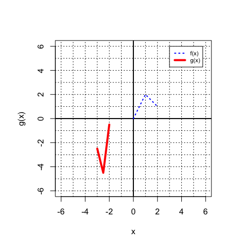

   - $a =$
   - $b =$
   - $h =$
   - $k =$

   Also, write the equation to define the daughter.

   $g(x) =$ $f($ $(x$ $)$

#### Question

5. A simple piece-wise function $f$ is plotted below.

   It’s general daughter function, having translations, reflections, and stretches, can be expressed with 4 parameters: $a$, $b$, $h$, and $k$.

   $$g(x) = a\, f(b(x-h))+k$$

   Compared to the parent function, the daughter is stretched vertically by a factor of $a$, stretched horizontally by a factor of $\frac{1}{b}$, and then shifted (translated) right $h$ and shifted up $k$.

   Notice, a left or down shift gives a negative value for $h$ or $k$. Also, a negative stretch factor causes a reflection.

   Each of those four parameters is randomly assigned $2$ or $-2$ or $\frac{1}{2}$ or $-\frac{1}{2}$. Determine the four parameters of the daughter by inspecting the daughter’s graph:

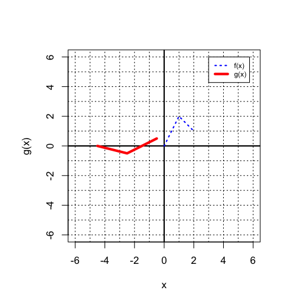

   - $a =$
   - $b =$
   - $h =$
   - $k =$

   Also, write the equation to define the daughter.

   $g(x) =$ $f($ $(x$ $)$

#### Question

6. A simple piece-wise function $f$ is plotted below.

   It’s general daughter function, having translations, reflections, and stretches, can be expressed with 4 parameters: $a$, $b$, $h$, and $k$.

   $$g(x) = a\, f(b(x-h))+k$$

   Compared to the parent function, the daughter is stretched vertically by a factor of $a$, stretched horizontally by a factor of $\frac{1}{b}$, and then shifted (translated) right $h$ and shifted up $k$.

   Notice, a left or down shift gives a negative value for $h$ or $k$. Also, a negative stretch factor causes a reflection.

   Each of those four parameters is randomly assigned $2$ or $-2$ or $\frac{1}{2}$ or $-\frac{1}{2}$. Determine the four parameters of the daughter by inspecting the daughter’s graph:

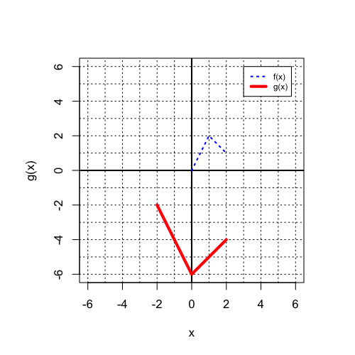

   - $a =$
   - $b =$
   - $h =$
   - $k =$

   Also, write the equation to define the daughter.

   $g(x) =$ $f($ $(x$ $)$

#### Question

7. A simple piece-wise function $f$ is plotted below.

   It’s general daughter function, having translations, reflections, and stretches, can be expressed with 4 parameters: $a$, $b$, $h$, and $k$.

   $$g(x) = a\, f(b(x-h))+k$$

   Compared to the parent function, the daughter is stretched vertically by a factor of $a$, stretched horizontally by a factor of $\frac{1}{b}$, and then shifted (translated) right $h$ and shifted up $k$.

   Notice, a left or down shift gives a negative value for $h$ or $k$. Also, a negative stretch factor causes a reflection.

   Each of those four parameters is randomly assigned $2$ or $-2$ or $\frac{1}{2}$ or $-\frac{1}{2}$. Determine the four parameters of the daughter by inspecting the daughter’s graph:

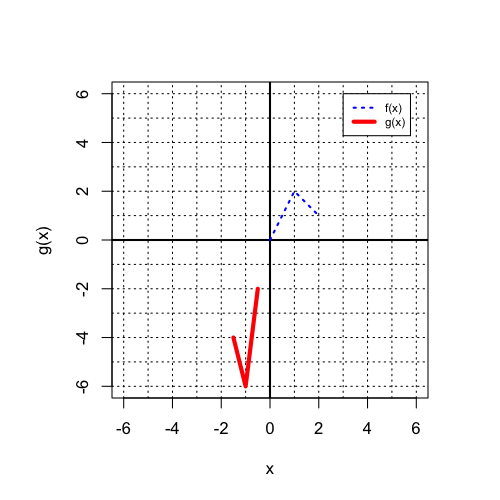

   - $a =$
   - $b =$
   - $h =$
   - $k =$

   Also, write the equation to define the daughter.

   $g(x) =$ $f($ $(x$ $)$

#### Question

8. A simple piece-wise function $f$ is plotted below.

   It’s general daughter function, having translations, reflections, and stretches, can be expressed with 4 parameters: $a$, $b$, $h$, and $k$.

   $$g(x) = a\, f(b(x-h))+k$$

   Compared to the parent function, the daughter is stretched vertically by a factor of $a$, stretched horizontally by a factor of $\frac{1}{b}$, and then shifted (translated) right $h$ and shifted up $k$.

   Notice, a left or down shift gives a negative value for $h$ or $k$. Also, a negative stretch factor causes a reflection.

   Each of those four parameters is randomly assigned $2$ or $-2$ or $\frac{1}{2}$ or $-\frac{1}{2}$. Determine the four parameters of the daughter by inspecting the daughter’s graph:

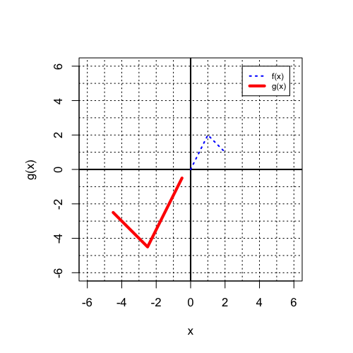

   - $a =$
   - $b =$
   - $h =$
   - $k =$

   Also, write the equation to define the daughter.

   $g(x) =$ $f($ $(x$ $)$